# Climate change | Assignment 1

Davide Pecchia

19/3/2018

## Introduction

There are many studies documenting that the average global temperature has been increasing over the last century. The consequences of this situation are sadly known. Among these, it is worth mentioning the rising ocean level and extreme weather events that are becoming increasingly frequent. In this assignment we analyze the relationship between the increase in global average temperature and other factors. The dataset `ClimateChange.csv` contains climate data form May 1983 to December 2008.

The variables of this data set are:

- **Year**: The observation year
- **Month**: The observation month
- **Temp**: The difference in degrees Celsius between the average global temperature in the observation month and a reference value
- **CFC.11**: The atmospheric concentration of trichlorofluoromethane (CFC-11), expressed in ppbv
- **CFC.12**: The atmospheric concentration of dichlorofluoromethane (CFC-12), expressed in ppbv
- **CO2**: The atmospheric concentration of carbon dioxide (CO2), expressed in ppmv
- **N2O**: The atmospheric concentration of nitrous oxide (N2O), expressed in ppmv
- **CH4**: The atmospheric concentration of methane (CH4), expressed in ppmv
- **Aerosols**: The mean stratospheric aerosol optical depth at 550 nm
- **TSI**: The total solar irradiance (TSI) in $W/m^2$
- **MEI**: Multivariate El Niño Southern Oscillation index, a measure of the strength of a weather effect in the Pacific Ocean

## Preprocessing

#### Libraries

Loading the needed packages for the analysis

```r
library(MASS)
library(plyr)
library(ggplot2)
library(knitr)
library(GGally)
suppressMessages(library(corrplot)) #hides the corrplot library startup message
```

#### Dataset

Loading the file `ClimateChange.csv` into the R environment to proceed with the analysis

```r
climate_change = read.csv(file ="Dataset/ClimateChange.csv")
str(climate_change)
```

```
## 'data.frame':    308 obs. of  11 variables:
##  $ Year    : int  1983 1983 1983 1983 1983 1983 1983 1983 1984 1984 ...
##  $ Month   : int  5 6 7 8 9 10 11 12 1 2 ...
##  $ MEI     : num  2.556 2.167 1.741 1.13 0.428 ...
##  $ CO2     : num  346 346 344 342 340 ...
##  $ CH4     : num  1639 1634 1633 1631 1648 ...
##  $ N2O     : num  304 304 304 304 304 ...
##  $ CFC.11  : num  191 192 193 194 194 ...
##  $ CFC.12  : num  350 352 354 356 357 ...
##  $ TSI     : num  1366 1366 1366 1366 1366 ...
##  $ Aerosols: num  0.0863 0.0794 0.0731 0.0673 0.0619 0.0569 0.0524 0.0486 0.0451 0.0416 ...
##  $ Temp    : num  0.109 0.118 0.137 0.176 0.149 0.093 0.232 0.078 0.089 0.013 ...
```

```r
kable(head(climate_change))
```

| Year | Month | MEI | CO2 | CH4 | N2O | CFC.11 | CFC.12 | TSI | Aerosols | Temp |
| --- | --- | --- | --- | --- | --- | --- | --- | --- | --- | --- |
| 1983 | 5 | 2.556 | 345.96 | 1638.59 | 303.677 | 191.324 | 350.113 | 1366.102 | 0.0863 | 0.109 |
| 1983 | 6 | 2.167 | 345.52 | 1633.71 | 303.746 | 192.057 | 351.848 | 1366.121 | 0.0794 | 0.118 |
| 1983 | 7 | 1.741 | 344.15 | 1633.22 | 303.795 | 192.818 | 353.725 | 1366.285 | 0.0731 | 0.137 |
| 1983 | 8 | 1.130 | 342.25 | 1631.35 | 303.839 | 193.602 | 355.633 | 1366.420 | 0.0673 | 0.176 |
| 1983 | 9 | 0.428 | 340.17 | 1648.40 | 303.901 | 194.392 | 357.465 | 1366.234 | 0.0619 | 0.149 |
| 1983 | 10 | 0.002 | 340.30 | 1663.79 | 303.970 | 195.171 | 359.174 | 1366.059 | 0.0569 | 0.093 |

Calculating the summary statistics for the dataset could be useful to obtain a better knowledge about the data used to solve the problem

```r
kable(summary(climate_change))
```

|  | Year | Month | MEI | CO2 | CH4 | N2O | CFC.11 | CFC.12 | TSI | Aerosols | Temp |
| --- | --- | --- | --- | --- | --- | --- | --- | --- | --- | --- | --- |
|  | Min. :1983 | Min. : 1.000 | Min. :-1.6350 | Min. :340.2 | Min. :1630 | Min. :303.7 | Min. :191.3 | Min. :350.1 | Min. :1365 | Min. :0.00160 | Min. :-0.2820 |
|  | 1st Qu.:1989 | 1st Qu.: 4.000 | 1st Qu.:-0.3987 | 1st Qu.:353.0 | 1st Qu.:1722 | 1st Qu.:308.1 | 1st Qu.:246.3 | 1st Qu.:472.4 | 1st Qu.:1366 | 1st Qu.:0.00280 | 1st Qu.: 0.1217 |
|  | Median :1996 | Median : 7.000 | Median : 0.2375 | Median :361.7 | Median :1764 | Median :311.5 | Median :258.3 | Median :528.4 | Median :1366 | Median :0.00575 | Median : 0.2480 |
|  | Mean :1996 | Mean : 6.552 | Mean : 0.2756 | Mean :363.2 | Mean :1750 | Mean :312.4 | Mean :252.0 | Mean :497.5 | Mean :1366 | Mean :0.01666 | Mean : 0.2568 |
|  | 3rd Qu.:2002 | 3rd Qu.:10.000 | 3rd Qu.: 0.8305 | 3rd Qu.:373.5 | 3rd Qu.:1787 | 3rd Qu.:317.0 | 3rd Qu.:267.0 | 3rd Qu.:540.5 | 3rd Qu.:1366 | 3rd Qu.:0.01260 | 3rd Qu.: 0.4073 |
|  | Max. :2008 | Max. :12.000 | Max. : 3.0010 | Max. :388.5 | Max. :1814 | Max. :322.2 | Max. :271.5 | Max. :543.8 | Max. :1367 | Max. :0.14940 | Max. : 0.7390 |

#### Creating test set and training set

To obtain a `training set` and a `test set` for the analysis, the original dataset is splitted into two subsets. The first partition, that we assume will be the `training set`, will contain observations up to and including year 2006, while the second partition will consist of observations after 2006.

```r
training_set = subset(climate_change, Year <= 2006)
test_set = subset(climate_change, Year > 2006)
str(training_set)
```

```
## 'data.frame':    284 obs. of  11 variables:
##  $ Year    : int  1983 1983 1983 1983 1983 1983 1983 1983 1984 1984 ...
##  $ Month   : int  5 6 7 8 9 10 11 12 1 2 ...
##  $ MEI     : num  2.556 2.167 1.741 1.13 0.428 ...
##  $ CO2     : num  346 346 344 342 340 ...
##  $ CH4     : num  1639 1634 1633 1631 1648 ...
##  $ N2O     : num  304 304 304 304 304 ...
##  $ CFC.11  : num  191 192 193 194 194 ...
##  $ CFC.12  : num  350 352 354 356 357 ...
##  $ TSI     : num  1366 1366 1366 1366 1366 ...
##  $ Aerosols: num  0.0863 0.0794 0.0731 0.0673 0.0619 0.0569 0.0524 0.0486 0.0451 0.0416 ...
##  $ Temp    : num  0.109 0.118 0.137 0.176 0.149 0.093 0.232 0.078 0.089 0.013 ...
```

```r
str(test_set)
```

```
## 'data.frame':    24 obs. of  11 variables:
##  $ Year    : int  2007 2007 2007 2007 2007 2007 2007 2007 2007 2007 ...
##  $ Month   : int  1 2 3 4 5 6 7 8 9 10 ...
##  $ MEI     : num  0.974 0.51 0.074 -0.049 0.183 ...
##  $ CO2     : num  383 384 385 386 387 ...
##  $ CH4     : num  1800 1803 1803 1802 1796 ...
##  $ N2O     : num  321 321 321 321 320 ...
##  $ CFC.11  : num  248 248 248 248 247 ...
##  $ CFC.12  : num  539 539 539 539 538 ...
##  $ TSI     : num  1366 1366 1366 1366 1366 ...
##  $ Aerosols: num  0.0054 0.0051 0.0045 0.0045 0.0041 0.004 0.004 0.0041 0.0042 0.0041 ...
##  $ Temp    : num  0.601 0.498 0.435 0.466 0.372 0.382 0.394 0.358 0.402 0.362 ...
```

```r
summary(training_set$Year) #summary of training set's variable Year
```

```
##    Min. 1st Qu.  Median    Mean 3rd Qu.    Max.
##    1983    1989    1995    1995    2001    2006
```

```r
summary(test_set$Year) #summary of test set's variable Year
```

```
##    Min. 1st Qu.  Median    Mean 3rd Qu.    Max.
##    2007    2007    2008    2008    2008    2008
```

A first look at the correlation between the variables of the dataset thanks to scatter matrix and scatter plots.

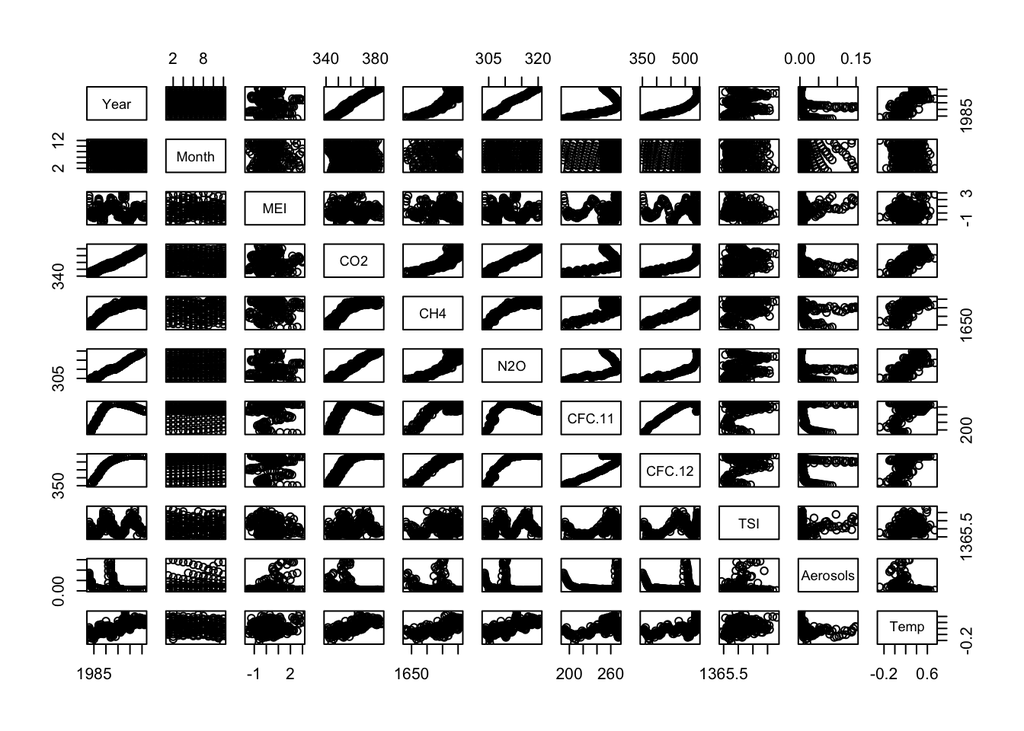

```r
pairs(training_set)
```

## Building the regression model

Here we start to build a linear regression model that predicts `Temp` using all of the other veriables (except `Year` and `Month`) and the `training set`.

```r
InitFormula = Temp ~ MEI + CO2 + CH4 + N2O + CFC.11 + CFC.12 + TSI + Aerosols
climate_regression = lm(formula = InitFormula, data = training_set)
options(scipen=4)
summary(climate_regression)
```

```
##
## Call:
## lm(formula = InitFormula, data = training_set)
##
## Residuals:
##      Min       1Q   Median       3Q      Max
## -0.25888 -0.05913 -0.00082  0.05649  0.32433
##
## Coefficients:
##                 Estimate   Std. Error t value Pr(>|t|)
## (Intercept) -124.5942604   19.8867999  -6.265 1.43e-09 ***
## MEI            0.0642053    0.0064702   9.923  < 2e-16 ***
## CO2            0.0064574    0.0022846   2.826  0.00505 **
## CH4            0.0001240    0.0005158   0.240  0.81015
## N2O           -0.0165280    0.0085649  -1.930  0.05467 .
## CFC.11        -0.0066305    0.0016260  -4.078 5.96e-05 ***
## CFC.12         0.0038081    0.0010135   3.757  0.00021 ***
## TSI            0.0931411    0.0147549   6.313 1.10e-09 ***
## Aerosols      -1.5376132    0.2132523  -7.210 5.41e-12 ***
## ---
## Signif. codes:  0 '***' 0.001 '**' 0.01 '*' 0.05 '.' 0.1 ' ' 1
##
## Residual standard error: 0.09171 on 275 degrees of freedom
## Multiple R-squared:  0.7509, Adjusted R-squared:  0.7436
## F-statistic: 103.6 on 8 and 275 DF,  p-value: < 2.2e-16
```

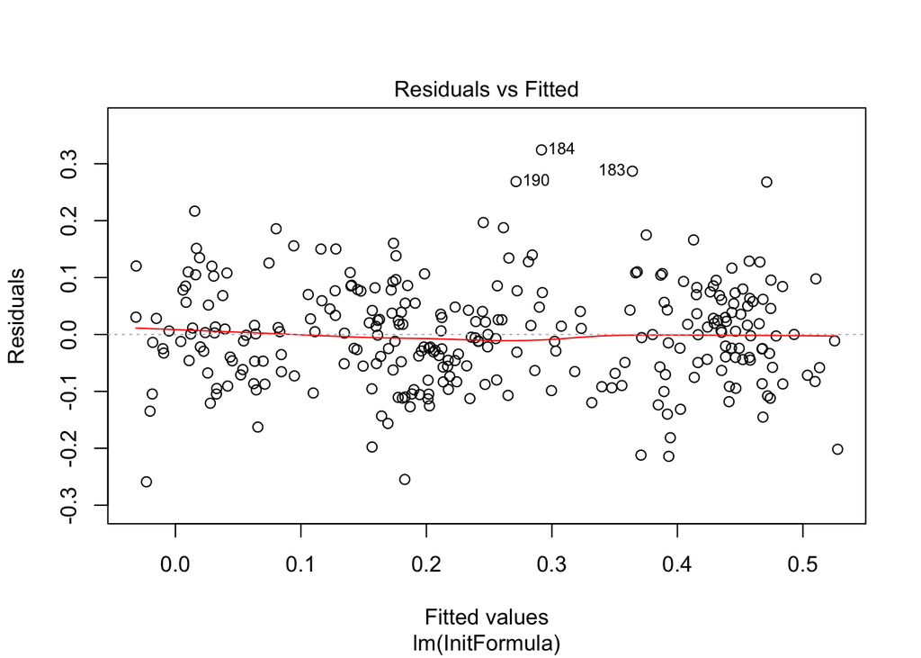

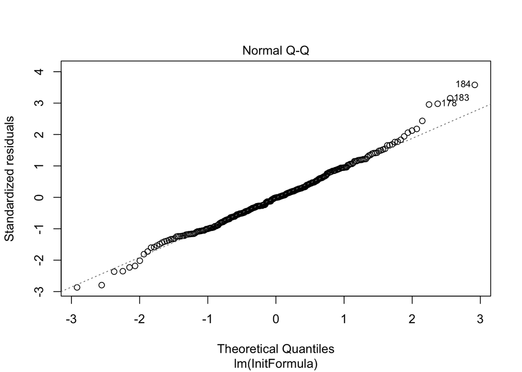

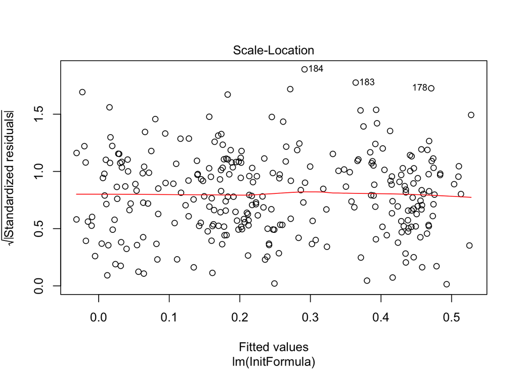

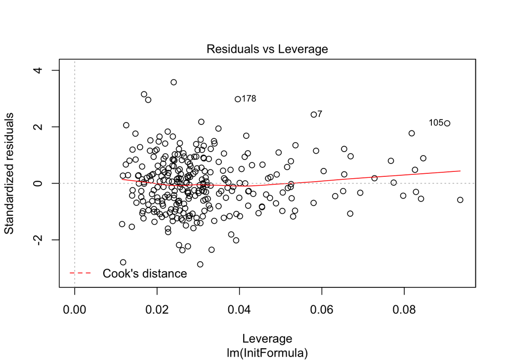

```r
plot(climate_regression)
```

#### Questions & Answers

- What is the linear regression equation produced by your model?

```r
climate_regression$coefficients
```

```
##     (Intercept)             MEI             CO2             CH4
## -124.5942604012    0.0642053134    0.0064573593    0.0001240419
##             N2O          CFC.11          CFC.12             TSI
##   -0.0165280033   -0.0066304889    0.0038081032    0.0931410835
##        Aerosols
##   -1.5376132381
```

$$Temp=-124.59426+0.06420\cdot MEI+0.00645\cdot CO2+0.00012\cdot CH4-0.01652\cdot N2O \\ -0.00663\cdot CFC.11+0.00380\cdot CFC.12+0.09314\cdot TSI-1.53761\cdot Aerosols$$

- Evaluate the quality of the model. What is the $R^2$ value? (*Multiple R-squared*). Which independent variables are significant?

```r
summary(climate_regression)
```

```
##
## Call:
## lm(formula = InitFormula, data = training_set)
##
## Residuals:
##      Min       1Q   Median       3Q      Max
## -0.25888 -0.05913 -0.00082  0.05649  0.32433
##
## Coefficients:
##                 Estimate   Std. Error t value Pr(>|t|)
## (Intercept) -124.5942604   19.8867999  -6.265 1.43e-09 ***
## MEI            0.0642053    0.0064702   9.923  < 2e-16 ***
## CO2            0.0064574    0.0022846   2.826  0.00505 **
## CH4            0.0001240    0.0005158   0.240  0.81015
## N2O           -0.0165280    0.0085649  -1.930  0.05467 .
## CFC.11        -0.0066305    0.0016260  -4.078 5.96e-05 ***
## CFC.12         0.0038081    0.0010135   3.757  0.00021 ***
## TSI            0.0931411    0.0147549   6.313 1.10e-09 ***
## Aerosols      -1.5376132    0.2132523  -7.210 5.41e-12 ***
## ---
## Signif. codes:  0 '***' 0.001 '**' 0.01 '*' 0.05 '.' 0.1 ' ' 1
##
## Residual standard error: 0.09171 on 275 degrees of freedom
## Multiple R-squared:  0.7509, Adjusted R-squared:  0.7436
## F-statistic: 103.6 on 8 and 275 DF,  p-value: < 2.2e-16
```

$R^2 = 0.7509$

The independent significant variables, considering $\alpha = 95\%$, are: `MEI`, `CO2`, `CFC.11`, `CFC.12`, `TSI`, `Aerosols`

- Current scientific opinion is that `N2O` and `CFC-11` are greenhouse gases. However, you should see that the regression coefficients of both variables are negative. What is the simplest explanation for this contradiction?

The variables in the dataset are strongly correlated so there’s a problem of multicollinearity. The heavy correlation causes some variables to be useless to explain and solve the problem.

- Compute the correlations between all independent variables in the training set.
  - Which variables is `N2O` highly correlated with (absolute correlation greater than 0.7)?
  - Which variables is `CFC.11` highly correlated with (absolute correlation greater than 0.7)?

```r
independent_variables = subset(training_set, select=c("MEI", "CO2", "CH4", "N2O", "CFC.11", "CFC.12", "Aerosols", "TSI"))
correlation = cor(independent_variables)
round(correlation,2)
```

```
##            MEI   CO2   CH4   N2O CFC.11 CFC.12 Aerosols   TSI
## MEI       1.00 -0.04 -0.03 -0.05   0.07   0.01     0.34 -0.15
## CO2      -0.04  1.00  0.88  0.98   0.51   0.85    -0.36  0.18
## CH4      -0.03  0.88  1.00  0.90   0.78   0.96    -0.27  0.25
## N2O      -0.05  0.98  0.90  1.00   0.52   0.87    -0.34  0.20
## CFC.11    0.07  0.51  0.78  0.52   1.00   0.87    -0.04  0.27
## CFC.12    0.01  0.85  0.96  0.87   0.87   1.00    -0.23  0.26
## Aerosols  0.34 -0.36 -0.27 -0.34  -0.04  -0.23     1.00  0.05
## TSI      -0.15  0.18  0.25  0.20   0.27   0.26     0.05  1.00
```

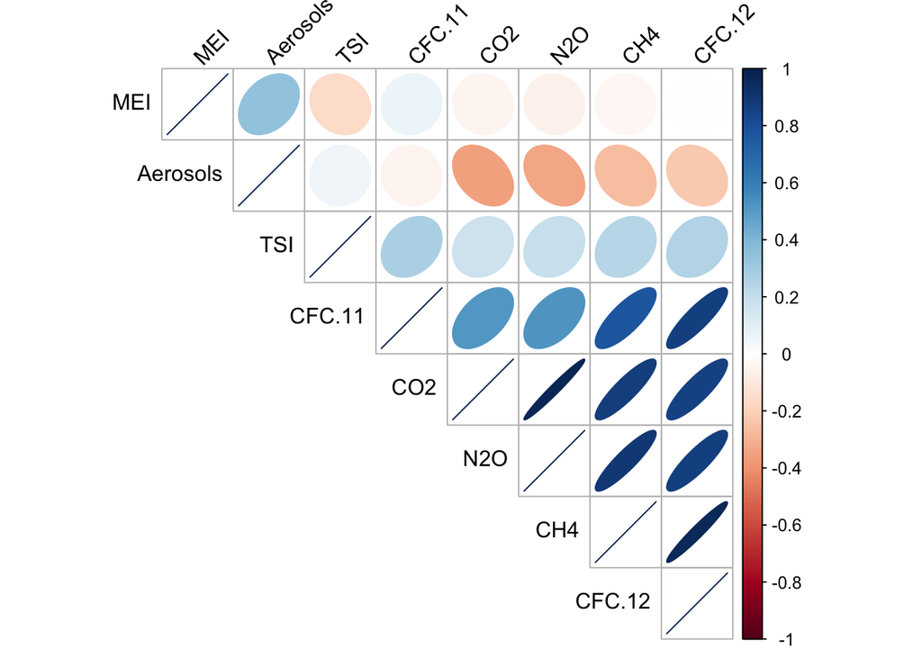

```r
corrplot(correlation, type = "upper", method = "ellipse", order = "hclust",
         tl.col = "black", tl.srt = 45)
```

The `N2O` variable is highly correlated with the variables: `CO2`, `CH4` and `CFC.12`.

The `CFC.11` variable is highly correlated with the variables: `CH4` and `CFC.12`

## Improving the regression model

Here we are improving the regression model building a new one using only `MEI`, `TSI`, `Aerosols`, and `N2O` as independent variables.

```r
FinalFormula = Temp ~ MEI + N2O + TSI + Aerosols
climate_regression = lm(formula = FinalFormula, data = training_set)
options(scipen=4)
summary(climate_regression)
```

```
##
## Call:
## lm(formula = FinalFormula, data = training_set)
##
## Residuals:
##      Min       1Q   Median       3Q      Max
## -0.27916 -0.05975 -0.00595  0.05672  0.34195
##
## Coefficients:
##                Estimate  Std. Error t value Pr(>|t|)
## (Intercept) -116.226858   20.223028  -5.747 2.37e-08 ***
## MEI            0.064186    0.006652   9.649  < 2e-16 ***
## N2O            0.025320    0.001311  19.307  < 2e-16 ***
## TSI            0.079490    0.014875   5.344 1.89e-07 ***
## Aerosols      -1.701737    0.217996  -7.806 1.19e-13 ***
## ---
## Signif. codes:  0 '***' 0.001 '**' 0.01 '*' 0.05 '.' 0.1 ' ' 1
##
## Residual standard error: 0.09547 on 279 degrees of freedom
## Multiple R-squared:  0.7261, Adjusted R-squared:  0.7222
## F-statistic: 184.9 on 4 and 279 DF,  p-value: < 2.2e-16
```

#### Questions & Answers

- How does the coefficient for `N2O` in this model compare to the coefficient in the previous one?

The `N2O` coefficient in this improved model is positive and assumes the value of 0.025320

- How does the quality of this model compare to the previous one? Consider the $R^2$ value and the significance of the independent variables when answering this question.

The new model performs worse than the previous one. It is clear considering the values of $R^2$ and $Adjusted R^2$ that are both smaller than those of the first model we’ve built. Furthermore, all the variables in this new model are significant but, considering the decrease of $R^2$ value, it emerges that some significant varibles are omitted and so the quality of the model decreases consequently.

## Out-of-sample validation

Eventually we apply the second model to the `test set` to check the performance on previously unseen data.

```r
climate_change_prediction = predict(climate_regression, newdata = test_set)
str(climate_change_prediction)
```

```
##  Named num [1:24] 0.504 0.475 0.451 0.439 0.451 ...
##  - attr(*, "names")= chr [1:24] "285" "286" "287" "288" ...
```

- Evaluate the quality of the prediction.

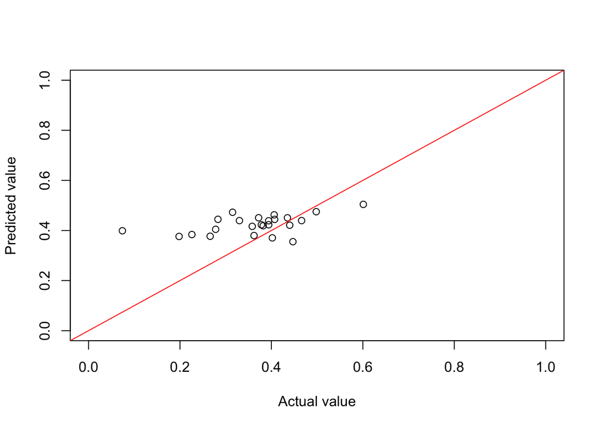

```r
plot(test_set$Temp, climate_change_prediction, xlim = c(0,1), ylim = c(0,1), xlab = "Actual value", ylab = "Predicted value")
abline(a=0,b=1, col="red")
```

- What is the $R^2$ on the testing set?

```r
SSE = sum((test_set$Temp - climate_change_prediction) ^ 2) # residuals
SST = sum((test_set$Temp - mean(training_set$Temp)) ^ 2)

1 - SSE / SST
```

```
## [1] 0.4967795
```

$R^2 = 0.4967795$

- What does this tell you about the model?

The model seems to overfit the `training set`, as is evident from the very low value of $R^2$ compared to the previous one.